# Causal considerations for the RoR project

Author

Sam Harper

Published

2026-09-03

## Purpose

This document tries to lay out some thinking about how to model whether reviewer characteristics like being a primary/secondary/tertiary reviewer vs. panelist or the level of expertise affect deviations from the consensus score.

```r
library(here)
library(dagitty)
source(here("code", "dag-helpers.R"))
```

`dag-helpers.R` vendors `drawdag()` and friends from Richard McElreath’s `rethinking` package ([source](https://github.com/rmcelreath/rethinking/blob/master/R/drawdag.R), GPL-3) rather than depending on the whole package, which pulls in rstan/cmdstanr build machinery not needed just to plot a DAG. It’s built on `dagitty` for DAG specification/layout and `shape::Arrows()` for the curved arrowheads.

## Aim 1: `exp` / `job` / `deviated`

Aim 1 is about how `job` and `expertise` may affect the likelihood of deviating from the consensus score (`deviated`) and/or the magnitude of that deviation (`deviation`). In terms of treatment assignment, the pool of potential reviewers self-assigns their level of expertise based on application titles and registration summaries.

> “Committee members are given access to application summaries to declare conflicts of interest and indicate their level of expertise, which are categorized as High, Medium, Low, or Not enough expertise. The Chairs, Scientific Officers and CIHR staff then assign each application to three committee members based on optimal alignment between the application content and the reviewer’s declared expertise” [^1]

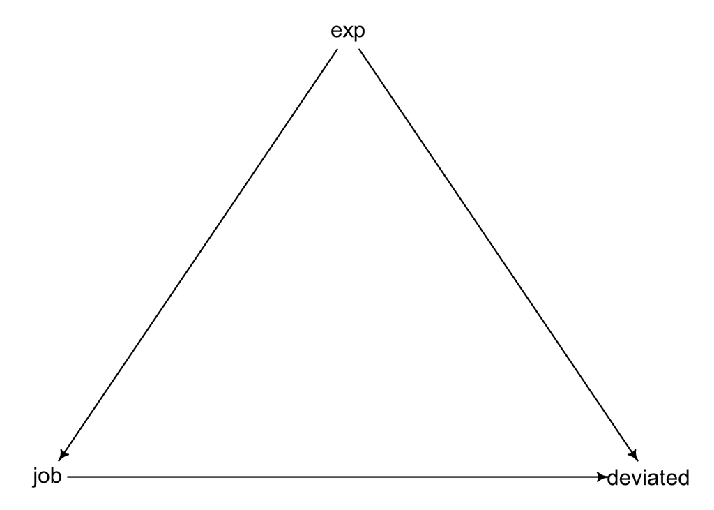

exp -> job -> deviated, exp -> deviated direct

```r
dag_aim1 <- dagitty("dag {
  exp -> job
  exp -> deviated
  job -> deviated
}")

coordinates(dag_aim1) <- list(
  x = c(exp = 1, job = 0, deviated = 2),
  y = c(exp = -1, job = 0, deviated = 0)
)

drawdag(dag_aim1, cex = 1.3)
```

`dagitty` confirms the adjustment sets match the by-hand reasoning in the research log:

```r
cat("total effect of exp on deviated:\n")
```

```
total effect of exp on deviated:
```

```r
print(adjustmentSets(dag_aim1, exposure = "exp", outcome = "deviated", effect = "total"))
```

```
 {}
```

```r
cat("\ndirect effect of exp on deviated (not through job):\n")
```

```
direct effect of exp on deviated (not through job):
```

```r
print(adjustmentSets(dag_aim1, exposure = "exp", outcome = "deviated", effect = "direct"))
```

```
{ job }
```

```r
cat("\ntotal effect of job on deviated:\n")
```

```
total effect of job on deviated:
```

```r
print(adjustmentSets(dag_aim1, exposure = "job", outcome = "deviated", effect = "total"))
```

```
{ exp }
```

- `exp`’s *total* effect needs no adjustment – matches the plain `deviated ~ exp` model (`m1` in the research log check).
- `exp`’s *direct* effect (net of role) needs `{job}` – matches `deviated ~ exp + job` (`m2`).
- `job`’s effect needs `{exp}` – `exp` is a genuine confounder of the `job -> deviated` relationship (a common cause of both), so `m2` is also the right specification for `job`’s own coefficient.

## Adding applicant characteristics as precision covariates

`job` stays the focal exposure. Applicant characteristics (gender, past funding success, age) plausibly predict the outcome but can’t plausibly affect anything about the reviewer side (`job`, `exp`) – nor could reviewer assignment retroactively cause an applicant’s gender or age. That makes them exogenous to the whole reviewer-side process, entering only through `deviated`: a textbook “precision covariate” pattern, not a confounder – a variable d-separated from the exposure can be added to reduce residual variance without opening any biasing path (Cinelli, Forney & Pearl’s “good control” case, opposite of the `exp`/`job` mediator situation above).

This is also conceptually distinct from Aim 2: these are *main-effect* precision covariates for `job`’s estimand here, not the effect-modification question Aim 2 actually asks (does `job`/`exp`’s *effect* differ *by* applicant characteristic). Both could coexist in the same model.

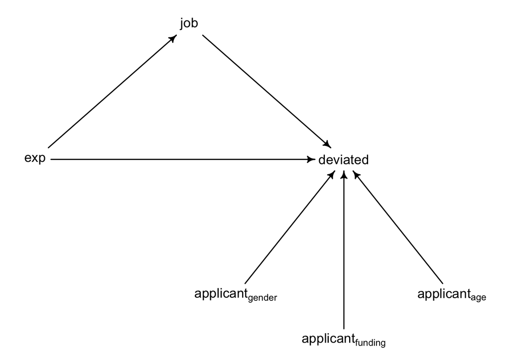

job as focal exposure, applicant characteristics as precision covariates on deviated only

```r
dag_aim1_precision <- dagitty("dag {
  exp -> job
  exp -> deviated
  job -> deviated
  applicant_gender -> deviated
  applicant_funding -> deviated
  applicant_age -> deviated
}")

exposures(dag_aim1_precision) <- "job"
outcomes(dag_aim1_precision)  <- "deviated"

coordinates(dag_aim1_precision) <- list(
  x = c(exp = 0, job = 1, deviated = 2,
        applicant_gender = 1.3, applicant_funding = 2, applicant_age = 2.7),
  y = c(exp = 0, job = -1.5, deviated = 0,
        applicant_gender = 1.5, applicant_funding = 2, applicant_age = 1.5)
)

drawdag(dag_aim1_precision, cex = 1.1)
```

```r
cat("total effect of job on deviated:\n")
```

```
total effect of job on deviated:
```

```r
print(adjustmentSets(dag_aim1_precision))
```

```
{ exp }
```

Adjustment set for `job` is unchanged (`{exp}`) – adding the applicant nodes doesn’t change *what* needs to be conditioned on for identification, only (potentially) how precisely it’s estimated, which is exactly the point of a precision covariate: it shouldn’t change the adjustment set at all.

## Open questions / where to take this next

- Test the precision-covariate claim empirically once applicant characteristics are actually in the simulation (Aim 2’s sim already has `gender`/`career_stage` – could check SE(`job`) with/without them as main effects on `deviated`, separate from Aim 2’s interaction question).
- Check with Matthew Hogel whether “past funding success” and “age” are extractable, independent of gender/career stage’s already-known status.

## Footnotes

[^1]: See [Peer Review Manual - Project](https://cihr-irsc.gc.ca/e/49564.html)